# DS 624: Homwork 3 (TS Decomposition)

## Problem 6.3

Recall your retail time series data (from Exercise 3 in Section 2.10). Decompose the series using X11. Does it reveal any outliers, or unusual features that you had not noticed previously?

> According to FPP2, Section 12.9: “Outliers are observations that are very different from the majority of the observations in the time series. They may be errors, or they may simply be unusual.”

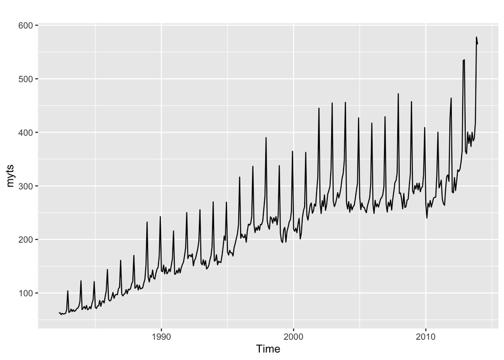

```r
retaildata <- readxl::read_excel("retail.xlsx", skip=1)
myts <- ts(retaildata[,"A3349873A"], frequency=12, start=c(1982,4))

autoplot(myts)
```

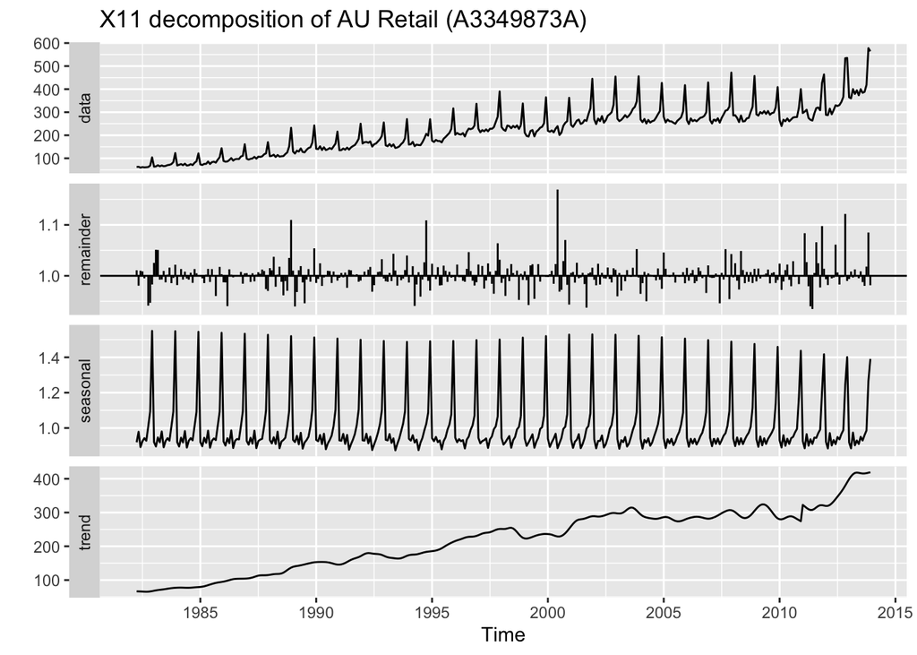

```r
fit_x11 <- myts %>% seas(x11="")

autoplot(fit_x11) +
  ggtitle("X11 decomposition of AU Retail (A3349873A)")
```

```r
fit_str <- myts %>% decompose(type='multiplicative')

(outlier_indices <- tsoutliers(myts))
```

```
## $index
## [1]  81 189 237 345 356 368 380
##
## $replacements
## [1] 200.1515 357.1622 411.0537 448.8968 338.7885 403.3957 444.0633
```

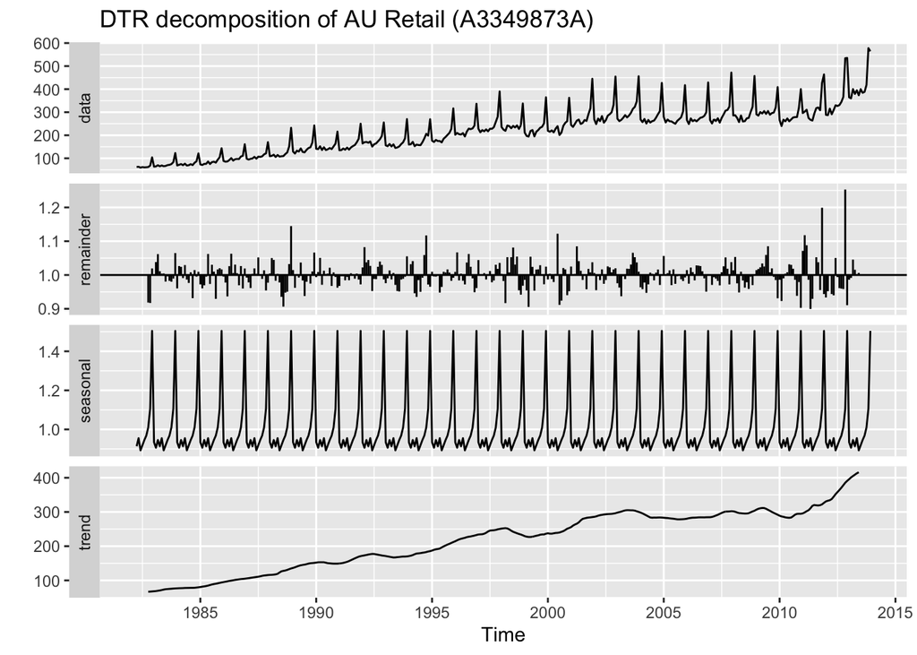

```r
autoplot(fit_str) +
  ggtitle("DTR decomposition of AU Retail (A3349873A)")
```

> We can see candidate outlier points at datapoins: 81 189 237 345 356 368 380. Since this is multiplicative, not additive, it’s harder to assess the low outliers compared with the high outliers as the remanied is technically compressed less than one. X11 drew more attention to outliers near 1988, 1994, and 2001, while the original STR drew more attention (via residuals) to ~2012`2013.